# Chapter 1 — The Problem with Statistics (R companion)

R/tidyverse translation of *Understanding Data by Alan Garfinkel and Yina Guo

Adrian Soto-Mota, MD, PhD, FACP.

2026-04-24

# Orientation

Chapter 1 (book pp. 17–22) is a narrative chapter — it has no code. It shows that a large fraction of the published scientific literature is unreliable, due to weak statistical practices (especially rigid reliance on `p < 0.05`, §1.3). Because the chapter contains no Python, this R companion illustrates the **diagnostic symptoms** the authors describes so that you can see them in real numbers before we learn the cures in later chapters.

Three symptoms are worth simulating here:

1. How often a true null gets “rejected” at the conventional α = 0.05 threshold.
2. How much a single arbitrary choice (the threshold itself) changes conclusions.
3. Why “statistically significant” does not mean “scientifically meaningful”.

> **Prerequisites for this series.** R ≥ 4.1 (native pipe `|>`), `tidyverse`, and — in later chapters — `ggbeeswarm`, `patchwork`, `splines`, `quantreg`, `pwr`. Install with `install.packages(c("tidyverse", "ggbeeswarm", "patchwork", "quantreg", "pwr"))`.

# Symptom 1 — α = 0.05 produces a lot of false alarms

*(Book §1.3, “Weak statistical standards”, pp. 21–22.)*

If we run a two-sample t-test on data drawn from the *same* distribution, the null hypothesis is literally true. Yet ~5 % of the time we get `p < 0.05`. Let’s check.

```r
# 10,000 experiments where groups A and B come from the same N(0,1) population
n_experiments <- 10000
n_per_group   <- 30

# A plain for-loop is clearer and faster than rowwise() here.
p_values <- numeric(n_experiments)
for (i in seq_len(n_experiments)) {
  A <- rnorm(n_per_group)   # group A, 30 obs, same population
  B <- rnorm(n_per_group)   # group B, 30 obs, same population
  p_values[i] <- t.test(A, B)$p.value
}
results <- tibble(p_value = p_values)

mean(results$p_value < 0.05)   # should be ≈ 0.05
```

```
## [1] 0.0488
```

That ≈ 5 % rate is *by construction* — α = 0.05 means “accept a 5 % false-alarm rate”. Across thousands of tests in the literature, that is a lot of spurious findings.

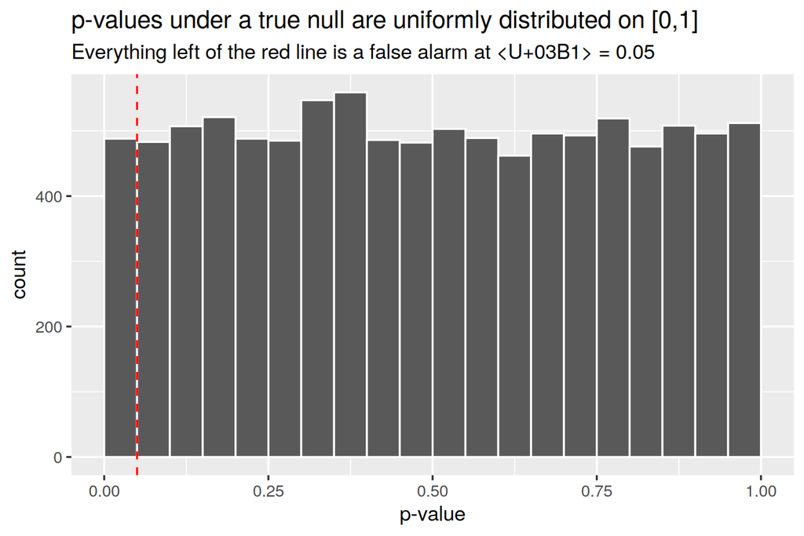

```r
ggplot(results, aes(p_value)) +
  geom_histogram(boundary = 0, binwidth = 0.05, color = "white") +
  geom_vline(xintercept = 0.05, linetype = "dashed", color = "red") +
  labs(title = "p-values under a true null are uniformly distributed on [0,1]",
       subtitle = "Everything left of the red line is a false alarm at α = 0.05",
       x = "p-value", y = "count")
```

The histogram is flat. Under the null, every p-value is equally likely — there is nothing special about 0.05 except that 5 % of the mass lies below it.

# Symptom 2 — the threshold is arbitrary

*(Book §1.3, “p-values and statistical significance”, p. 22 — and Ch. 3 §3.3 p. 132, “α = 0.05 is not strong enough; use α = 0.01 or better 0.001”.)*

The chapter urges using α = 0.01 or 0.001 instead. Count the same 10,000 experiments at three thresholds:

```r
results |>
  summarise(
    `α = 0.05`  = mean(p_value < 0.05),
    `α = 0.01`  = mean(p_value < 0.01),
    `α = 0.001` = mean(p_value < 0.001)
  )
```

```
## # A tibble: 1 x 3
##   `\u03b1 = 0.05` `\u03b1 = 0.01` `\u03b1 = 0.001`
##             <dbl>           <dbl>            <dbl>
## 1          0.0488          0.0091           0.0005
```

Moving the threshold is the entire difference between a “positive” and a “negative” study, even though the data never changed. That fragility is the author’s point.

# Symptom 3 — significance ≠ importance

*(Previews book §3.3 “NHST gives us no clue as to effect size”, p. 142.)*

With a large enough sample, trivially small effects become “significant”.

```r
# True mean difference of 0.05 SD — almost nothing clinically
tiny_effect <- function(n) {
  A <- rnorm(n, mean = 0.00, sd = 1)
  B <- rnorm(n, mean = 0.05, sd = 1)   # 0.05 SD shift
  t.test(A, B)$p.value
}

# At n = 50 per group, the tiny effect is usually not detected.
# At n = 50,000 per group, it almost always is.
tibble(
  n_per_group = c(50, 500, 5000, 50000),
  p_value     = map_dbl(n_per_group, tiny_effect)
)
```

```
## # A tibble: 4 x 2
##   n_per_group  p_value
##         <dbl>    <dbl>
## 1          50 8.01e- 1
## 2         500 8.91e- 2
## 3        5000 7.52e- 2
## 4       50000 5.10e-18
```

# What’s next

The remaining chapters build up the tools:

| Chapter | Tool |
| --- | --- |
| 2 | Dot/beeswarm plots, histograms, KDEs |
| 3 | Simulation-based p-values, the null world |
| 4 | Confidence intervals by resampling |
| 6–8 | Comparing groups, proportions, chi-squared |
| 9–10 | Correlation, regression |
| 11 | Statistical power |
| 12 | Bayesian updating and PPV |

Every subsequent `.Rmd` in this series follows the same structure: orientation, faithful simulation, then the idiomatic R shortcut where one exists.